# Segmentación de glóbulos blancos para imágenes de células plasmáticas en tejido neoplásico

Herramientas de bioinformática

De Pablo Diego

# 1 **Introducción**

En este trabajo, se aborda la *segmentación de glóbulos blancos* en imágenes de *células plasmáticas obtenidas de tejido neoplásico*. La segmentación de imágenes médicas es crucial en el análisis automatizado de datos biomédicos, ya que permite identificar regiones de interés dentro de una muestra. Utilizando algoritmos de mixturas de gaussianas, nuestro objetivo es detectar los glóbulos blancos, que se presentan teñidos de color morado en las imágenes, además de descubrir otros posibles grupos de interés dentro del tejido neoplásico. Esta técnica nos ayudará a mejorar la precisión en el diagnóstico y análisis de las muestras celulares.

# 2 **Objetivos**

1. **Segmentar glóbulos blancos en imágenes de células plasmáticas en tejido neoplásico** utilizando un modelo de mixturas de gaussianas.
2. **Detectar y analizar otros grupos celulares** presentes en las imágenes, que puedan ser de relevancia para el diagnóstico.

**Expande más si quieres leer **información de las imágenes que se usarán**

El conjunto de datos utilizado consiste en **85 imágenes en formato BMP**, cada una con dimensiones de **2560x1920 píxeles**. Estas imágenes contienen células plasmáticas teñidas de manera específica para resaltar los glóbulos blancos, que se presentan en tonos morados. Las imágenes usadas en este trabajo corresponden a Gupta, R., & Gupta, A. (2019). MiMM_SBILab Dataset: Microscopic Images of Multiple Myeloma [Data set]. The Cancer Imaging Archive. https://doi.org/10.7937/tcia.2019.pnn6aypl Las imágenes microscópicas se obtuvieron de portaobjetos de aspirado de médula ósea de pacientes con diagnóstico de mieloma múltiple según las pautas estándar. Los portaobjetos se tiñeron con tinción de Jenner-Giemsa. Las imágenes se capturaron con un aumento de 1000x utilizando un microscopio Nikon Eclipse-200 equipado con una cámara digital.

# 3 **Librerías**

Para llevar a cabo la segmentación de glóbulos blancos, utilizaremos las siguientes librerías de R:

- **`bmp`**: Para cargar imágenes en formato BMP.
- **`mclust`**: Para ajustar un modelo de mixturas de gaussianas.
- **`imager`**: Para procesar y visualizar imágenes.
- **`RColorBrewer`**: Para generar paletas de colores.

```r
# Función para cargar paquetes, instala si no está disponible
cargar_paquete <- function(paquete) {
  if (!requireNamespace(paquete, quietly = TRUE)) {
    install.packages(paquete, dependencies = TRUE)
  }
  library(paquete, character.only = TRUE)
}

# Verificar e instalar los paquetes necesarios
cargar_paquete("bmp")
cargar_paquete("mclust")
cargar_paquete("imager")
cargar_paquete("RColorBrewer")
```

# 4 **Carga de imágenes**

Para comenzar, cargaremos las imágenes de entrenamiento que utilizaremos para ajustar nuestro modelo de mixturas de gaussianas. Estas imágenes contienen células plasmáticas teñidas, con glóbulos blancos que se presentan en tonos morados. A continuación, cargaremos las imágenes y extraeremos los patrones de píxeles que utilizaremos para entrenar el modelo.

```r
# Directorio de las imágenes
carpeta_entrenamiento <- "entrenamiento/"
archivos_entrenamiento <- list.files(carpeta_entrenamiento, pattern = "\\.bmp$", full.names = TRUE)
```

## 4.1 **Procesamiento de imágenes**

Para facilitar el análisis y la segmentación de las imágenes, realizaremos un preprocesamiento que incluye la conversión a escala de grises y el redimensionamiento de las imágenes. Este paso nos permitirá trabajar con imágenes más pequeñas y en escala de grises, lo que simplificará el análisis de los patrones de píxeles.

```r
# Función para redimensionar y normalizar las imágenes
procesar_imagen <- function(ruta_imagen, escala = 0.2) {
  img <- load.image(ruta_imagen)  # Cargar la imagen
  dimensiones_originales <- dim(img)  # Guardar las dimensiones originales
  img_redimensionada <- resize(img, round(dimensiones_originales[1] * escala), round(dimensiones_originales[2] * escala))  # Redimensionar
  img_max <- max(img_redimensionada)
  if (img_max == 0) img_max <- 1  # Evitar división por cero
  img_normalizada <- img_redimensionada / img_max  # Normalizar entre 0 y 1
  return(list(imagen = img_normalizada, dimensiones = dimensiones_originales))
}

# Extraer los valores de píxeles de una imagen (convertir a dataframe)
extraer_pixeles <- function(img) {
  # Si la imagen tiene más de una capa, convertir a escala de grises
  if (spectrum(img) > 1) {
    img <- grayscale(img)
  }

  valores <- as.vector(img)  # Convertir la imagen a un vector de píxeles
  valores_df <- as.data.frame(valores)  # Convertir el vector a dataframe
  colnames(valores_df) <- c("intensidad")  # Nombrar la columna
  return(valores_df)
}

# Procesar todas las imágenes de entrenamiento
imagenes_procesadas <- lapply(archivos_entrenamiento, function(archivo) procesar_imagen(archivo)$imagen)

# Extraer los píxeles de todas las imágenes procesadas y combinarlas en un solo dataframe
pixeles_entrenamiento <- do.call(rbind, lapply(imagenes_procesadas, extraer_pixeles))
```

# 5 **Segmentación de glóbulos blancos**

Existe una variedad de algoritmos y técnicas para segmentar imágenes, dependiendo de la naturaleza de los datos y el objetivo de la segmentación. En este caso, utilizaremos un modelo de mixturas de gaussianas para segmentar los glóbulos blancos en las imágenes de células plasmáticas. Este modelo nos permitirá identificar grupos de píxeles con características similares y asignarlos a diferentes clusters, lo que facilitará la detección de los glóbulos blancos en las imágenes.

## 5.1 **Mixturas de Gaussianas:**

Las mixturas de gaussianas son un modelo probabilístico que se utiliza para describir la distribución de datos en un espacio multidimensional. En el contexto de la segmentación de imágenes, las mixturas de gaussianas se utilizan para modelar la distribución de los píxeles en una imagen y detectar grupos de píxeles que comparten características similares.

En nuestro caso, utilizaremos un modelo de mixturas de gaussianas para segmentar los glóbulos blancos en las imágenes de células plasmáticas. Ajustaremos el modelo con las imágenes de entrenamiento y luego lo aplicaremos a las imágenes de validación para identificar los glóbulos blancos en cada imagen.

```r
# Entrenar el modelo de Mixtura Gaussiana con los píxeles de las imágenes de entrenamiento
modelo_mclust <- Mclust(pixeles_entrenamiento)

# Ver el número óptimo de clusters
k_optimo <- modelo_mclust$G
cat("Número óptimo de clusters (k):", k_optimo, "\n")
```

```
## Número óptimo de clusters (k): 9
```

## 5.2 **Segmentación de imágenes de prueba**

Una vez que hemos ajustado nuestro modelo de mixturas de gaussianas con las imágenes de entrenamiento, podemos aplicarlo a las imágenes de prueba para segmentar los glóbulos blancos.

Se comparara con una imagen sencilla y otra más complicada. En esta se puede observar que es una figura sencilla y se puede observar los eritrocito y los leucocitos, de manera que no esta tan sobrecargada la imagen.

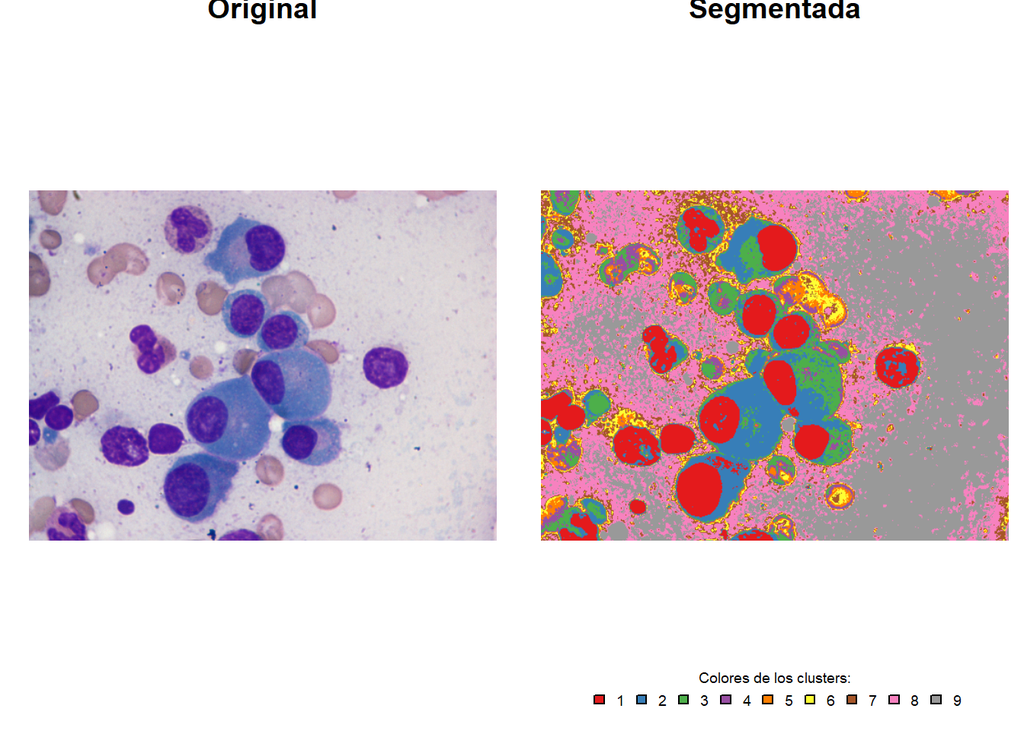

```r
# Probar el modelo en una imagen de la carpeta de test
carpeta_test <- "test/"
imagen_test_info <- procesar_imagen(paste0(carpeta_test, "500.bmp"))
imagen_test_procesada <- imagen_test_info$imagen  # Obtener la imagen procesada
dim_imagen_test <- imagen_test_info$dimensiones  # Obtener las dimensiones originales de la imagen

# Extraer los valores de los píxeles de la imagen de prueba
pixeles_test <- extraer_pixeles(imagen_test_procesada)

# Predecir los clusters para la imagen de prueba
segmentacion_test <- predict(modelo_mclust, newdata = pixeles_test)$classification

# Asegúrate de que el tamaño de la matriz coincida con el de la imagen redimensionada
dim_imagen_redimensionada <- dim(imagen_test_procesada)[1:2]
if (length(segmentacion_test) != prod(dim_imagen_redimensionada)) {
  stop("La longitud de la segmentación no coincide con las dimensiones de la imagen redimensionada")
}

# Reconstruir la imagen segmentada
imagen_segmentada <- matrix(segmentacion_test, nrow = dim_imagen_redimensionada[1], ncol = dim_imagen_redimensionada[2])

# Asignar colores a los clusters
colores <- brewer.pal(k_optimo, "Set1")  # Colores diferentes para cada cluster

# Crear una nueva imagen coloreada según la clasificación de los clusters
imagen_coloreada <- array(0, dim = c(dim_imagen_redimensionada[1], dim_imagen_redimensionada[2], 3))  # Crear un array vacío para 3 canales (RGB)
for (i in 1:k_optimo) {
  mascara_cluster <- imagen_segmentada == i  # Crear una máscara para cada cluster
  imagen_coloreada[,,1][mascara_cluster] <- col2rgb(colores[i])[1] / 255  # Canal rojo
  imagen_coloreada[,,2][mascara_cluster] <- col2rgb(colores[i])[2] / 255  # Canal verde
  imagen_coloreada[,,3][mascara_cluster] <- col2rgb(colores[i])[3] / 255  # Canal azul
}

# Convertir la imagen coloreada a un objeto 'cimg'
imagen_coloreada_cimg <- as.cimg(imagen_coloreada)

# Mostrar la imagen original sin bordes adicionales
par(mfrow=c(1,2))  # Para mostrar ambas imágenes juntas
par(mar=c(0.5, 1, 0.5, 0.5))  # Eliminar márgenes
# Mostrar la imagen original con título
plot(imagen_test_info$imagen, axes=FALSE, main="Original")

# Mostrar la imagen segmentada con título
plot(imagen_coloreada_cimg, axes=FALSE, main="Segmentada")
# Ajustar el espacio para la leyenda
par(mar=c(0, 0, 0, 0))  # Espacio para la leyenda debajo

# Agregar la leyenda con un tamaño de texto más pequeño debajo de la imagen
legend("bottom", legend = paste( 1:k_optimo), fill = colores, title = "Colores de los clusters:", horiz = TRUE, cex = 0.6, bty = "n")
```

## 5.3 **Otro ejemplo más complicado**

A diferencia del anterior en esta imagen se puede observar que esta más sobrecargada de información y con muchas más células en total.

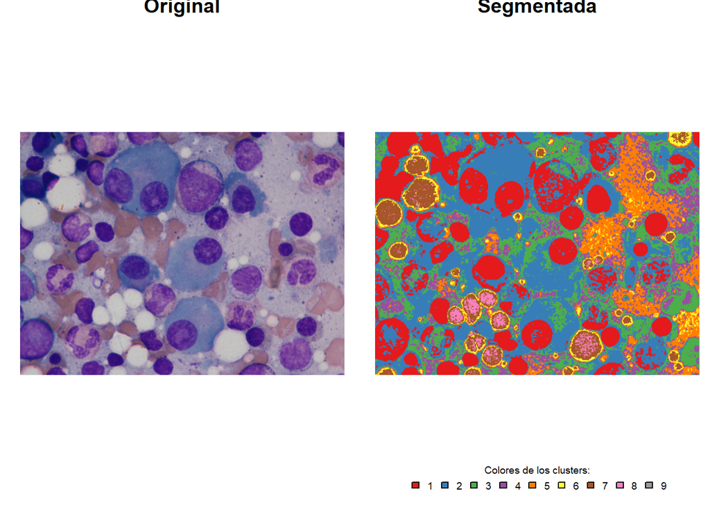

```r
# Probar el modelo en una imagen de la carpeta de test
carpeta_test <- "test/"
imagen_test_info <- procesar_imagen(paste0(carpeta_test, "514.bmp"))
imagen_test_procesada <- imagen_test_info$imagen  # Obtener la imagen procesada
dim_imagen_test <- imagen_test_info$dimensiones  # Obtener las dimensiones originales de la imagen

# Extraer los valores de los píxeles de la imagen de prueba
pixeles_test <- extraer_pixeles(imagen_test_procesada)

# Predecir los clusters para la imagen de prueba
segmentacion_test <- predict(modelo_mclust, newdata = pixeles_test)$classification

# Asegúrate de que el tamaño de la matriz coincida con el de la imagen redimensionada
dim_imagen_redimensionada <- dim(imagen_test_procesada)[1:2]
if (length(segmentacion_test) != prod(dim_imagen_redimensionada)) {
  stop("La longitud de la segmentación no coincide con las dimensiones de la imagen redimensionada")
}

# Reconstruir la imagen segmentada
imagen_segmentada <- matrix(segmentacion_test, nrow = dim_imagen_redimensionada[1], ncol = dim_imagen_redimensionada[2])

# Asignar colores a los clusters
colores <- brewer.pal(k_optimo, "Set1")  # Colores diferentes para cada cluster

# Crear una nueva imagen coloreada según la clasificación de los clusters
imagen_coloreada <- array(0, dim = c(dim_imagen_redimensionada[1], dim_imagen_redimensionada[2], 3))  # Crear un array vacío para 3 canales (RGB)
for (i in 1:k_optimo) {
  mascara_cluster <- imagen_segmentada == i  # Crear una máscara para cada cluster
  imagen_coloreada[,,1][mascara_cluster] <- col2rgb(colores[i])[1] / 255  # Canal rojo
  imagen_coloreada[,,2][mascara_cluster] <- col2rgb(colores[i])[2] / 255  # Canal verde
  imagen_coloreada[,,3][mascara_cluster] <- col2rgb(colores[i])[3] / 255  # Canal azul
}

# Convertir la imagen coloreada a un objeto 'cimg'
imagen_coloreada_cimg <- as.cimg(imagen_coloreada)

# Mostrar la imagen original sin bordes adicionales
par(mfrow=c(1,2))  # Para mostrar ambas imágenes juntas
par(mar=c(0.5, 1, 0.5, 0.5))  # Eliminar márgenes
# Mostrar la imagen original con título
plot(imagen_test_info$imagen, axes=FALSE, main="Original")

# Mostrar la imagen segmentada con título
plot(imagen_coloreada_cimg, axes=FALSE, main="Segmentada")
# Ajustar el espacio para la leyenda
par(mar=c(0, 0, 0, 0))  # Espacio para la leyenda debajo

# Agregar la leyenda con un tamaño de texto más pequeño debajo de la imagen
legend("bottom", legend = paste( 1:k_optimo), fill = colores, title = "Colores de los clusters:", horiz = TRUE, cex = 0.6, bty = "n")
```